# Chuck/Zong total-scRNA: understand the data, then check cell quality

**Dictyostelium · 0 h and 16 h · 8 September 2026**

This notebook is a guided first cell-quality review for our splicing project. Read it from top to bottom; the tables and plots are generated from the saved counts.

We will introduce the dataset, look at a small gene-expression table, explain the biological question, and then examine quality without using the intron/length result to select cells. Original data and previous analyses are not overwritten. **An outlier flag is a reason to investigate, not proof that a cell is damaged.**

## 1. What data do we have?

These are the **Chuck/Zong total-RNA single-cell libraries**, not the supporting 10x poly(A) dataset and not Rosengarten bulk RNA. The [snapTotal-seq methods paper](https://www.nature.com/articles/s41467-024-50291-3) explains the total-RNA approach; our Dictyostelium counts use our own audited mapping and stricter molecule-classification policy.

The existing technical audit records 158 completed libraries at 0 h and 174 at 16 h. Three additional 0 h inputs did not finish processing; those are **processing gaps**, not cells rejected by biological QC.

Each library has a cell identifier and plate label. We use **time point + plate** as a QC group; a repeated plate label does not establish paired cells or biological replication.

The reference is **Reference 3, `dd_chrFL_2024.gtf`**, matching these alignments. The saved tables cover 12,873 annotated mRNA gene IDs. The *assay* captures total RNA, but this *count matrix* is an mRNA-feature matrix, not all RNA biotypes. Ribosomal RNA therefore also needs a read-level diagnostic.

A UMI is a short molecular label used to collapse repeated reads. Here labels are only five bases long, so these are deduplicated gene/cell observations, not guaranteed exact molecule numbers: collisions can merge different molecules.

```python
from pathlib import Path
import sys, json, platform
from datetime import datetime, timezone

import numpy as np
import pandas as pd
import matplotlib.pyplot as plt
from IPython.display import display, Markdown

# Locate the repository whether launched from its root or notebooks/.
ROOT = next(p for p in (Path.cwd(), *Path.cwd().parents)
            if (p / "analysis/splicing_speed_comparison/audit_chuck.py").is_file())
sys.path.insert(0, str(ROOT / "analysis/splicing_speed_comparison"))
from prepare_intron_length_test import digest, read_mapping

RESULTS = ROOT / "results/splicing_speed_comparison"
RECLASSIFIED = RESULTS / "chuck_reclassified"
RUN_UTC = datetime.now(timezone.utc).strftime("%Y%m%dT%H%M%S%fZ")
OUT = RESULTS / "chuck_cell_qc" / RUN_UTC
OUT.mkdir(parents=True, exist_ok=False)  # A fresh output folder on each execution.
input_hashes = {}

def record_input(path):
    input_hashes[str(path.relative_to(ROOT))] = digest(path)
    return path

audit = json.loads(record_input(RESULTS / "chuck_audit_20260908.json").read_text())
run = json.loads(record_input(RECLASSIFIED / "RUN_METADATA.json").read_text())
assert audit["technical_count_checks"] == "PASS"
GTF = ROOT / "data/references/source/reference_3/dd_chrFL_2024.gtf"
assert digest(record_input(GTF)) == run["gtf_sha256"] == audit["gtf_sha256"]
for name in ("prepare_intron_length_test.py", "build_gene_structure.py"):
    record_input(ROOT / "analysis/splicing_speed_comparison" / name)

# Select quality/identity fields only; intron counts and fractions do not enter QC.
fields = ["sample", "hour", "plate", "raw_pairs", "exon_umis",
          "unique_mapping_pct", "valid_read2_fraction",
          "gene_cell_pairs_at_least_900_candidate_umis"]
meta = pd.DataFrame(audit["cells"])[fields].sort_values(["hour", "plate", "sample"])
meta = meta.set_index("sample")
assert meta.index.is_unique and len(meta) == run["cells"]
meta["qc_group"] = meta["hour"] + "h_" + meta["plate"]
meta["cell_label"] = [f"C{i:03d}" for i in range(1, len(meta) + 1)]
pd.set_option("display.max_columns", 16)
pd.set_option("display.max_colwidth", 90)
plt.rcParams.update({"figure.dpi": 115, "axes.spines.top": False,
                     "axes.spines.right": False, "font.size": 10})

inventory = pd.DataFrame([
    {"time": h + " h", "input libraries": c["input_cells"],
     "completed libraries": c["counted_cells"], "processing gaps": len(c["missing_cells"])}
    for h, c in audit["cohorts"].items()
])
display(inventory)
display(meta.groupby(["hour", "plate"]).size().rename("completed libraries").to_frame())
```

|  | time | input libraries | completed libraries | processing gaps |
| --- | --- | --- | --- | --- |
| 0 | 00 h | 161 | 158 | 3 |
| 1 | 16 h | 174 | 174 | 0 |

| hour | plate | completed libraries |
| --- | --- | --- |
| 00 | P2 | 72 |
|  | P3 | 86 |
| 16 | P1 | 88 |
|  | P3 | 86 |

### Load the actual expression matrix

Rows will be genes, columns will be cells, and entries will be **raw exon-only UMI counts**. Zero means “not detected here,” not proof that the gene is biologically absent. These are not TPM, percentages, or normalized expression.

We reuse the reclassified per-cell files rather than older summary tables. The checks below verify gene IDs, nonnegative integer counts, agreement with the audited cell totals, and agreement with the saved gene aggregates.

```python
# Load saved counts and small mapping summaries only: no FASTQ/BAM scan.
columns, contigs = {}, {}
gene_names = None
for sample, row in meta.iterrows():
    path = RECLASSIFIED / (row["hour"] + "hr") / sample / (sample + ".exon_barcode_count.txt")
    frame = pd.read_csv(record_input(path), sep="\t").set_index("Gene_id")
    assert frame.index.is_unique
    values = frame["UMI_count"]
    assert pd.api.types.is_integer_dtype(values) and values.between(0, 1024).all()
    if gene_names is None:
        gene_names = frame["Gene_name"].sort_index()
    assert set(frame.index) == set(gene_names.index)
    columns[sample] = values.reindex(gene_names.index)
    path = ROOT / ("results/snap_total_" + row["hour"] + "hr") / sample / "alignment_contigs.tsv"
    mapped = pd.read_csv(record_input(path), sep="\t", header=None,
                         names=["contig", "length", "mapped", "unmapped"])
    assert mapped["contig"].is_unique
    contigs[sample] = mapped.set_index("contig")["mapped"]

exon = pd.DataFrame(columns, dtype=np.int32)
assert exon.columns.equals(meta.index) and not exon.isna().any().any()
assert np.array_equal(exon.sum().to_numpy(), meta["exon_umis"].to_numpy())
aggregate = pd.read_csv(record_input(RESULTS / "chuck_gene_counts.tsv"), sep="\t").set_index("gene_id")
assert aggregate.index.is_unique and set(aggregate.index) == set(exon.index)
for hour in ("00", "16"):
    selected = meta.index[meta["hour"].eq(hour)]
    for metric, values in [("exon_umis", exon[selected].sum(axis=1)),
                           ("cells_exon_detected", exon[selected].gt(0).sum(axis=1))]:
        assert np.array_equal(values.to_numpy(),
                              aggregate.loc[exon.index, f"chuck_{hour}hr_{metric}"].to_numpy())

models = read_mapping(GTF, set(exon.index))
assert set(models) == set(exon.index)
chrom = pd.Series({g: models[g]["chrom"] for g in exon.index})
nuclear_ids = chrom.index[chrom.isin([f"chr{i}" for i in range(1, 7)])]
mito_ids = chrom.index[chrom.eq("chrM")]
assert len(mito_ids) > 0
nuclear = exon.loc[nuclear_ids]
mapped_reads = pd.DataFrame(contigs).fillna(0).astype(np.int64)
print(f"Verified expression matrix: {exon.shape[0]:,} genes × {exon.shape[1]} cells.")
print(f"Main nuclear chromosomes: {len(nuclear_ids):,} mRNA IDs; chrM: {len(mito_ids)}.")
print("All cell totals and both time-point gene aggregates agree with the saved audit.")
```

```
Verified expression matrix: 12,873 genes × 332 cells.
Main nuclear chromosomes: 12,743 mRNA IDs; chrM: 41.
All cell totals and both time-point gene aggregates agree with the saved audit.
```

```python
# Small illustrative table: three cells per time point; eight detected genes.
example_cells = [s for h in ("00", "16") for s in meta.index[meta["hour"].eq(h)][:3]]
example_genes = nuclear.index[nuclear.gt(0).sum(axis=1).ge(5)][:8]
example = exon.loc[example_genes, example_cells].rename(columns=meta["cell_label"])
example.insert(0, "gene name", gene_names.loc[example_genes])
display(example)
display(meta.loc[example_cells, ["cell_label", "hour", "plate"]].reset_index())
display(Markdown("For example, a value of **7** means seven distinct exon-only UMI labels "
                 "were counted for that gene in that cell. This small table illustrates the format; "
                 "it is not a representative biological comparison."))
```

|  | gene name | C001 | C002 | C003 | C159 | C160 | C161 |
| --- | --- | --- | --- | --- | --- | --- | --- |
| DDB_G0267178 | DDB_G0267178_RTE | 0 | 0 | 0 | 0 | 0 | 0 |
| DDB_G0267182 | DDB_G0267182_RTE | 1 | 0 | 0 | 0 | 0 | 0 |
| DDB_G0267184 | DDB_G0267184_RTE | 0 | 0 | 0 | 0 | 0 | 0 |
| DDB_G0267188 | DDB_G0267188_RTE | 0 | 0 | 0 | 0 | 0 | 0 |
| DDB_G0267206 | DDB_G0267206_RTE | 0 | 0 | 0 | 0 | 0 | 0 |
| DDB_G0267210 | DDB_G0267210_RTE | 0 | 0 | 0 | 0 | 0 | 0 |
| DDB_G0267236 | DDB_G0267236_RTE | 0 | 0 | 0 | 2 | 1 | 1 |
| DDB_G0267238 | DDB_G0267238_RTE | 0 | 0 | 0 | 0 | 0 | 0 |

|  | sample | cell_label | hour | plate |
| --- | --- | --- | --- | --- |
| 0 | Dicty_D0_P2_AACGCAGT | C001 | 00 | P2 |
| 1 | Dicty_D0_P2_AAGACGAG | C002 | 00 | P2 |
| 2 | Dicty_D0_P2_AAGCAACT | C003 | 00 | P2 |
| 3 | Dicty_16h_P1_AAGACGAG | C159 | 16 | P1 |
| 4 | Dicty_16h_P1_AAGCAACT | C160 | 16 | P1 |
| 5 | Dicty_16h_P1_AATGTACG | C161 | 16 | P1 |

For example, a value of **7** means seven distinct exon-only UMI labels were counted for that gene in that cell. This small table illustrates the format; it is not a representative biological comparison.

## 2. What are we trying to find out?

Our question is why we detect so little intronic RNA. One proposed explanation is rapid splicing: introns may be removed soon after transcription. We have begun asking whether genes with detected introns have longer genes or longer introns.

**Before trusting that comparison, we need to know whether some cells have unusually poor RNA capture or unusual library composition.** Such cells could have fewer opportunities to detect any RNA.

This notebook asks a narrower question: *which libraries look technically unusual relative to comparable libraries?* It does not measure splicing speed, compare length effects, or choose cells to strengthen our hypothesis. Intronic fractions and gene lengths are never QC thresholds.

## 3. QC guidance—and how we adapt it

[OSCA's basic QC chapter](https://bioconductor.org/books/release/OSCA.basic/quality-control.html) uses library depth, detected genes, and mitochondrial proportions, with log-transformed count metrics and adaptive outlier thresholds. Diagnostic plots help distinguish quality problems from genuine biology.

[OSCA's batch-aware guidance](https://bioconductor.org/books/release/OSCA.advanced/quality-control-redux.html) recommends within-batch thresholds when distributions differ. This assumes most cells in each batch are usable; it cannot identify an entirely failed batch by itself. We therefore show the groups side by side.

[Single-cell Best Practices](https://www.sc-best-practices.org/preprocessing-visualization/quality-control/) stresses interpreting metrics jointly. A high mitochondrial signal alone need not mean cell damage, and high counts alone do not prove a doublet. Its worked example is human data, so we do **not** import its mitochondrial percentage cutoff or human gene-name prefixes.

**Our explicit adaptation:** use main-chromosome exon-only UMIs for depth and gene detection, keeping mitochondrial signal separate and avoiding direct selection on the intron outcome. Use the mapping GTF's chrM assignments, not `MT-` prefixes. Show both UMI- and read-level mitochondrial measurements: their denominators differ. chrR mapping is a ribosomal-contig proxy, not the fraction of UMIs in ribosomal-protein genes.

### Which measurements mean what?

| Measurement | Plain-language meaning | How we use it |
| --- | --- | --- |
| Nuclear exon UMIs | Captured exon signal from chr1–chr6 | Unusually low: core review flag |
| Nuclear genes detected | Different chr1–chr6 genes with at least one exon UMI | Unusually low: core review flag |
| Mitochondrial exon UMI % | chrM exon UMIs / all mRNA-feature exon UMIs | Unusually high: core review flag |
| Mitochondrial read % | Unique reads mapped to chrM / all unique mapped reads | Supporting flag; not interchangeable with UMI % |
| chrR read % | Unique reads on the ribosomal reference contig / all unique reads | Composition diagnostic; not an automatic exclusion |
| Unique mapping and valid Read2 % | Alignment success and accepted barcode/UMI-primer read evidence | Technical diagnostics |
| Top-20-gene share; high depth/features | Concentrated or unusually large expression profiles | Review only; not a doublet diagnosis |

All original genes remain in the loaded matrix. The nuclear subset is used to calculate QC metrics, not to replace the gene catalog. Read2 validity is measured among candidate transcript-assigned reads, not among all sequenced reads.

```python
qc = meta.drop(columns="exon_umis").copy()
qc["exon_umis_total"] = exon.sum()
qc["n_genes_all"] = exon.gt(0).sum()
qc["nuclear_exon_umis"] = nuclear.sum()
qc["nuclear_genes_detected"] = nuclear.gt(0).sum()
qc["pct_mito_exon_umis"] = 100 * exon.loc[mito_ids].sum() / qc["exon_umis_total"]
qc["pct_mito_unique_reads"] = 100 * mapped_reads.loc["chrM"] / mapped_reads.sum()
qc["pct_chrR_unique_reads"] = 100 * mapped_reads.loc["chrR"] / mapped_reads.sum()
qc["valid_read2_pct"] = 100 * qc.pop("valid_read2_fraction")
qc["pct_top20_nuclear"] = 100 * np.sort(nuclear.to_numpy(), axis=0)[-20:].sum(axis=0) / qc["nuclear_exon_umis"]
assert np.isfinite(qc.select_dtypes("number")).all().all()
assert qc["nuclear_exon_umis"].gt(0).all()
assert qc["nuclear_genes_detected"].gt(0).all()
for metric in ("pct_mito_exon_umis", "pct_mito_unique_reads", "pct_chrR_unique_reads",
               "unique_mapping_pct", "valid_read2_pct", "pct_top20_nuclear"):
    assert qc[metric].between(0, 100).all()
display(qc.groupby("qc_group").agg(
    cells=("hour", "size"), median_nuclear_UMIs=("nuclear_exon_umis", "median"),
    median_nuclear_genes=("nuclear_genes_detected", "median"),
    median_mito_UMI_pct=("pct_mito_exon_umis", "median"),
    median_mito_read_pct=("pct_mito_unique_reads", "median"),
    median_chrR_read_pct=("pct_chrR_unique_reads", "median")
).round(2))
```

| qc_group | cells | median_nuclear_UMIs | median_nuclear_genes | median_mito_UMI_pct | median_mito_read_pct | median_chrR_read_pct |
| --- | --- | --- | --- | --- | --- | --- |
| 00h_P2 | 72 | 85264.0 | 5145.0 | 2.63 | 5.23 | 54.88 |
| 00h_P3 | 86 | 94318.0 | 5416.5 | 2.76 | 5.72 | 52.62 |
| 16h_P1 | 88 | 24857.0 | 3192.0 | 1.48 | 3.21 | 74.68 |
| 16h_P3 | 86 | 22059.0 | 3081.5 | 1.52 | 4.24 | 71.59 |

## 4. Define review flags before inspecting length results

We use **3 scaled median absolute deviations (MADs)** in the concerning direction for low depth, low detected genes, and high mitochondrial UMI percentage. A MAD measures how far typical observations lie from their group median. Here `scaled MAD = 1.4826 × median(|x − median(x)|)`, following the [R MAD convention](https://stat.ethz.ch/R-manual/R-devel/library/stats/html/mad.html). This is not the same numeric rule as five *unscaled* MADs in the Best Practices example.

Depth and detected genes use log2 values; percentages stay on their original scale. Each time-point/plate group gets its own thresholds. If a metric has zero MAD, the code reports it and avoids silently treating every deviation as bad.

We also record supporting diagnostic outliers. High depth/features use a more permissive five-scaled-MAD screen. **Any core flag means “review,” not “confirmed low quality.”** A flag-free list is saved only as a candidate sensitivity cohort, not automatically applied to the splicing analysis. These are transparent screening choices, not validated Dictyostelium-specific cutoffs.

```python
# A small reusable calculation; no intron counts or gene lengths are passed here.
def flag_outliers(data, metric, direction, log=False, nmads=3):
    flags = pd.Series(False, index=data.index)
    rows = []
    for group, frame in data.groupby("qc_group", sort=True):
        values = frame[metric].to_numpy(dtype=float)
        transformed = np.log2(values) if log else values
        center = float(np.median(transformed))
        spread = float(1.4826 * np.median(np.abs(transformed - center)))
        cutoff = center + (1 if direction == "high" else -1) * nmads * spread
        valid = bool(spread > 0 and np.isfinite(spread))
        if valid:
            flags.loc[frame.index] = transformed > cutoff if direction == "high" else transformed < cutoff
        rows.append(dict(qc_group=group, metric=metric, direction=direction, nmads=nmads,
                         log2=log, median_transformed=center, scaled_mad=spread,
                         threshold_original_units=float(2 ** cutoff if log else cutoff),
                         active=valid, n_cells=len(frame), flagged=int(flags.loc[frame.index].sum())))
    return flags, rows

rules = {
    "low_nuclear_umis": ("nuclear_exon_umis", "low", True, 3),
    "low_nuclear_genes": ("nuclear_genes_detected", "low", True, 3),
    "high_mito_umis": ("pct_mito_exon_umis", "high", False, 3),
    "high_mito_reads": ("pct_mito_unique_reads", "high", False, 3),
    "high_chrR_reads": ("pct_chrR_unique_reads", "high", False, 3),
    "low_unique_mapping": ("unique_mapping_pct", "low", False, 3),
    "low_valid_read2": ("valid_read2_pct", "low", False, 3),
    "high_top20_share": ("pct_top20_nuclear", "high", False, 3),
    "high_nuclear_umis": ("nuclear_exon_umis", "high", True, 5),
    "high_nuclear_genes": ("nuclear_genes_detected", "high", True, 5),
}
threshold_rows = []
for name, (metric, direction, log, nmads) in rules.items():
    qc[name], rows = flag_outliers(qc, metric, direction, log, nmads)
    threshold_rows.extend(dict(flag=name, **row) for row in rows)
thresholds = pd.DataFrame(threshold_rows)
core_flags = ["low_nuclear_umis", "low_nuclear_genes", "high_mito_umis"]
diagnostic_flags = [name for name in rules if name not in core_flags]
qc["core_review"] = qc[core_flags].any(axis=1)
qc["diagnostic_review"] = qc[diagnostic_flags].any(axis=1)
qc["core_reasons"] = qc[core_flags].apply(lambda r: "; ".join(r.index[r]), axis=1)
qc["diagnostic_reasons"] = qc[diagnostic_flags].apply(lambda r: "; ".join(r.index[r]), axis=1)
qc["qc_status"] = np.select([qc["core_review"], qc["diagnostic_review"]],
                           ["core review", "diagnostic review only"], default="no screen flags")
display(thresholds.loc[thresholds["flag"].isin(core_flags),
                       ["qc_group", "flag", "threshold_original_units", "active", "flagged"]].round(3))
if not thresholds["active"].all():
    display(Markdown("**Zero-spread thresholds need manual review:**"))
    display(thresholds.loc[~thresholds["active"]])
```

|  | qc_group | flag | threshold_original_units | active | flagged |
| --- | --- | --- | --- | --- | --- |
| 0 | 00h_P2 | low_nuclear_umis | 34657.505 | True | 2 |
| 1 | 00h_P3 | low_nuclear_umis | 31594.610 | True | 5 |
| 2 | 16h_P1 | low_nuclear_umis | 4875.724 | True | 0 |
| 3 | 16h_P3 | low_nuclear_umis | 6056.135 | True | 1 |
| 4 | 00h_P2 | low_nuclear_genes | 3881.017 | True | 2 |
| 5 | 00h_P3 | low_nuclear_genes | 4034.085 | True | 5 |
| 6 | 16h_P1 | low_nuclear_genes | 1367.284 | True | 0 |
| 7 | 16h_P3 | low_nuclear_genes | 1780.664 | True | 2 |
| 8 | 00h_P2 | high_mito_umis | 3.604 | True | 0 |
| 9 | 00h_P3 | high_mito_umis | 3.570 | True | 2 |
| 10 | 16h_P1 | high_mito_umis | 3.319 | True | 3 |
| 11 | 16h_P3 | high_mito_umis | 2.955 | True | 4 |

## 5. Look at the distributions

Each dot below is one cell. Boxes summarize the middle half of each group's values. Orange outlines identify core-review cells; red dashes show the relevant within-group screen threshold.

Look for isolated outliers **and** whole-group shifts. A shift affecting most 16 h cells is not, by itself, evidence that those cells are bad.

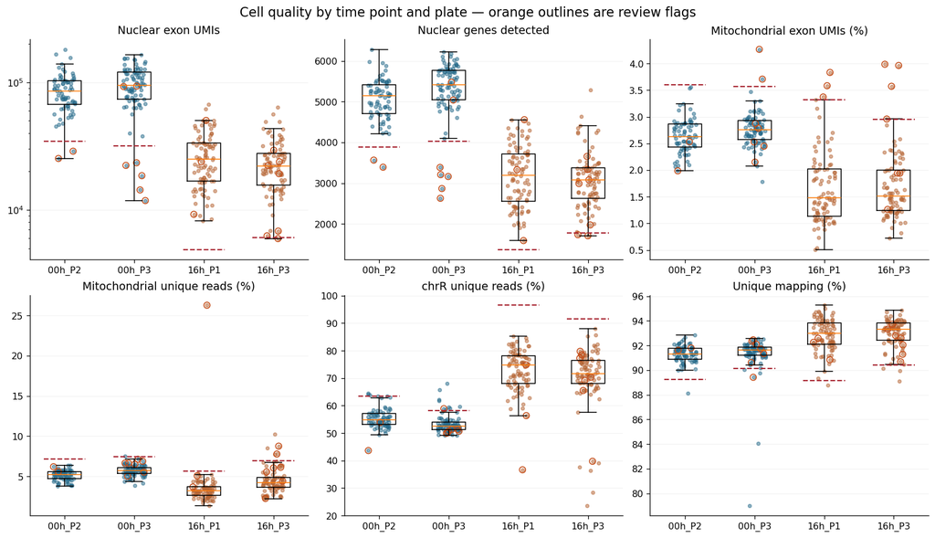

```python
groups = sorted(qc["qc_group"].unique())
colors = {"00": "#256a8a", "16": "#b66534"}
panels = [
    ("nuclear_exon_umis", "Nuclear exon UMIs", "low_nuclear_umis", True),
    ("nuclear_genes_detected", "Nuclear genes detected", "low_nuclear_genes", False),
    ("pct_mito_exon_umis", "Mitochondrial exon UMIs (%)", "high_mito_umis", False),
    ("pct_mito_unique_reads", "Mitochondrial unique reads (%)", "high_mito_reads", False),
    ("pct_chrR_unique_reads", "chrR unique reads (%)", "high_chrR_reads", False),
    ("unique_mapping_pct", "Unique mapping (%)", "low_unique_mapping", False),
]
rng = np.random.default_rng(20260908)
fig, axes = plt.subplots(2, 3, figsize=(14, 8), constrained_layout=True)
for ax, (metric, title, flag, logscale) in zip(axes.flat, panels):
    values = [qc.loc[qc["qc_group"].eq(g), metric].to_numpy() for g in groups]
    ax.boxplot(values, positions=range(len(groups)), widths=.48, showfliers=False)
    for i, group in enumerate(groups):
        frame = qc.loc[qc["qc_group"].eq(group)]
        x = i + rng.uniform(-.16, .16, len(frame))
        ax.scatter(x, frame[metric], s=13, c=colors[group[:2]], alpha=.5)
        marked = frame["core_review"].to_numpy()
        ax.scatter(x[marked], frame.loc[frame["core_review"], metric],
                   s=44, facecolors="none", edgecolors="#c44b16", linewidths=1)
        threshold = thresholds.loc[thresholds["qc_group"].eq(group) & thresholds["flag"].eq(flag)].iloc[0]
        if threshold["active"]:
            ax.hlines(threshold["threshold_original_units"], i-.3, i+.3,
                      colors="#a82632", linestyles="--", linewidth=1.4)
    ax.set_xticks(range(len(groups)), groups)
    ax.set_title(title)
    if logscale:
        ax.set_yscale("log")
    ax.grid(axis="y", alpha=.15)
fig.suptitle("Cell quality by time point and plate — orange outlines are review flags", fontsize=14)
fig.savefig(OUT / "qc_distributions.png", dpi=150)
plt.show()
```

### Check metrics together

The left panels ask whether low RNA depth also means fewer detected genes; color shows mitochondrial UMI percentage. The right panels compare two **different** mitochondrial fractions. Read fractions include mapped RNA outside the mRNA UMI matrix and are affected by amplification; the five-base UMI space can also compress highly expressed genes.

To keep labels readable, each time point labels its two lowest-depth cells and its highest mitochondrial-read cell. Orange outlines mark all core-review cells. Full cell IDs are available in the lookup table below. A high mitochondrial percentage with otherwise strong RNA capture is a review case, not an automatic diagnosis of membrane damage.

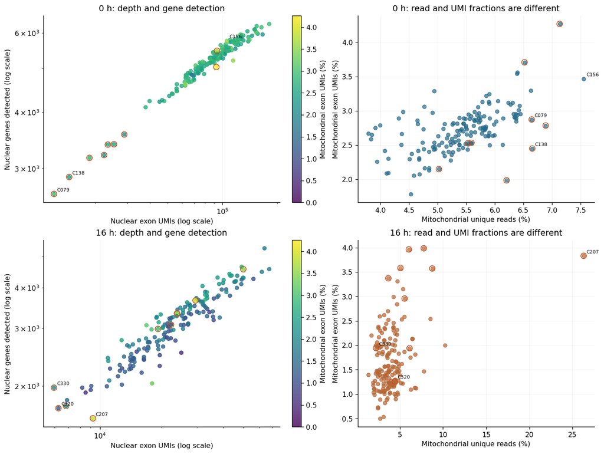

```python
fig, axes = plt.subplots(2, 2, figsize=(12, 9), constrained_layout=True)
vmax = float(qc["pct_mito_exon_umis"].max())
for row, hour in enumerate(("00", "16")):
    frame = qc.loc[qc["hour"].eq(hour)]
    left, right = axes[row]
    points = left.scatter(frame["nuclear_exon_umis"], frame["nuclear_genes_detected"],
                          c=frame["pct_mito_exon_umis"], cmap="viridis", vmin=0, vmax=vmax,
                          s=28, alpha=.8)
    left.set(xscale="log", yscale="log", xlabel="Nuclear exon UMIs (log scale)",
             ylabel="Nuclear genes detected (log scale)", title=f"{int(hour)} h: depth and gene detection")
    fig.colorbar(points, ax=left, label="Mitochondrial exon UMIs (%)")
    right.scatter(frame["pct_mito_unique_reads"], frame["pct_mito_exon_umis"],
                  c=colors[hour], s=28, alpha=.7)
    right.set(xlabel="Mitochondrial unique reads (%)", ylabel="Mitochondrial exon UMIs (%)",
              title=f"{int(hour)} h: read and UMI fractions are different")
    marked = frame.loc[frame["core_review"]]
    left.scatter(marked["nuclear_exon_umis"], marked["nuclear_genes_detected"],
                 s=65, facecolors="none", edgecolors="#c44b16", linewidths=1)
    right.scatter(marked["pct_mito_unique_reads"], marked["pct_mito_exon_umis"],
                  s=65, facecolors="none", edgecolors="#c44b16", linewidths=1)
    label_ids = frame.nsmallest(2, "nuclear_exon_umis").index.union(
        frame.nlargest(1, "pct_mito_unique_reads").index)
    for sample, cell in frame.loc[label_ids].iterrows():
        left.annotate(cell["cell_label"], (cell["nuclear_exon_umis"], cell["nuclear_genes_detected"]),
                      xytext=(4, 4), textcoords="offset points", fontsize=7)
        right.annotate(cell["cell_label"], (cell["pct_mito_unique_reads"], cell["pct_mito_exon_umis"]),
                       xytext=(4, 4), textcoords="offset points", fontsize=7)
    for ax in (left, right):
        ax.grid(alpha=.15)
fig.savefig(OUT / "qc_joint_metrics.png", dpi=150)
plt.show()
```

## 6. Which cells need review?

The table separates core flags from supporting diagnostics. Flags can overlap, so per-reason counts should not be added to obtain a total. “No screen flags” means only that these screens found no outlier; it is not a singlet certificate or proof that every assay step worked.

No intron/length result is recalculated here. We preserve all cells and save their flags, thresholds, and identities so any later exclusion is explicit and reproducible.

```python
summary = qc.groupby(["hour", "plate", "qc_status"]).size().unstack(fill_value=0)
display(summary)
display(qc.groupby("qc_group")[list(rules)].sum().T)
with pd.option_context("display.max_rows", None):
    display(Markdown("### Core review: depth, gene detection or mitochondrial UMIs"))
    display(qc.loc[qc["core_review"]].set_index("cell_label")[
        ["qc_group", "nuclear_exon_umis", "nuclear_genes_detected",
         "pct_mito_exon_umis", "pct_mito_unique_reads", "core_reasons"]].round(3))
    display(Markdown("### Supporting diagnostics (including overlaps with core flags)"))
    display(qc.loc[qc["diagnostic_review"]].set_index("cell_label")[
        ["qc_group", "unique_mapping_pct", "valid_read2_pct",
         "pct_chrR_unique_reads", "diagnostic_reasons"]].round(3))

# Full identifiers remain accessible without making every metric table too wide.
from IPython.display import HTML
lookup = qc.loc[qc["core_review"] | qc["diagnostic_review"], ["cell_label"]].reset_index()
display(HTML("<details><summary>Expand full cell-identifier lookup</summary>"
             + lookup.to_html(index=False) + "</details>"))

medians = qc.groupby("hour")[["nuclear_exon_umis", "nuclear_genes_detected",
                             "pct_chrR_unique_reads"]].median()
extreme = qc.loc[qc["pct_mito_unique_reads"].idxmax()]
low_both = qc["low_nuclear_umis"] & qc["low_nuclear_genes"]
display(Markdown(f"""### What the results mean in this run

- **{int(qc['core_review'].sum())} cells need core review**, and another
  **{int((qc['diagnostic_review'] & ~qc['core_review']).sum())}** have diagnostic-only flags.
  **{int((~qc['core_review'] & ~qc['diagnostic_review']).sum())}** have no screen flags.
- Median nuclear exon depth is **{medians.loc['00', 'nuclear_exon_umis']:,.0f} UMIs at 0 h**
  versus **{medians.loc['16', 'nuclear_exon_umis']:,.0f} at 16 h**.
  Median chrR read share is **{medians.loc['00', 'pct_chrR_unique_reads']:.1f}%**
  versus **{medians.loc['16', 'pct_chrR_unique_reads']:.1f}%**.
  This is a group-wide difference, not grounds to reject the entire 16 h cohort.
- **{extreme['cell_label']} ({extreme.name})** deserves early inspection:
  **{extreme['pct_mito_unique_reads']:.2f}% mitochondrial reads**, but
  **{extreme['pct_mito_exon_umis']:.2f}% mitochondrial exon UMIs**, with
  **{extreme['nuclear_exon_umis']:,} nuclear exon UMIs** and
  **{extreme['nuclear_genes_detected']:,} detected nuclear genes**.
  The disagreement demonstrates why these percentages cannot be substituted for one another.
- **{int(low_both.sum())} cells** are low outliers for both depth and gene detection.
  The two metrics are correlated; two flags do not constitute two independent diagnoses.
- **No cells have been removed.** Review-only mitochondrial outliers with strong
  RNA capture should not be labeled damaged solely from a relative percentage.
"""))

# Repeated barcode-level failures can suggest a systematic technical issue.
barcode_qc = qc.assign(barcode=qc.index.str.rsplit("_", n=1).str[-1])
repeated = barcode_qc.groupby("barcode").agg(
    libraries=("hour", "size"), low_Read2_flags=("low_valid_read2", "sum"))
repeated = repeated.loc[(repeated["libraries"] >= 2) &
                        repeated["libraries"].eq(repeated["low_Read2_flags"])]
if len(repeated):
    display(Markdown("### A repeated-barcode technical clue\n"
                     "These barcodes have low Read2 validation in every occurrence. "
                     "This suggests a sequence-linked issue to investigate, not proof that all "
                     "affected cells are poor quality."))
    display(repeated)
    display(barcode_qc.loc[barcode_qc["barcode"].isin(repeated.index),
                          ["cell_label", "qc_group", "barcode", "valid_read2_pct"]])
```

| hour | qc_status plate | core review | diagnostic review only | no screen flags |
| --- | --- | --- | --- | --- |
| 00 | P2 | 2 | 5 | 65 |
|  | P3 | 7 | 12 | 67 |
| 16 | P1 | 3 | 2 | 83 |
|  | P3 | 7 | 7 | 72 |

| qc_group | 00h_P2 | 00h_P3 | 16h_P1 | 16h_P3 |
| --- | --- | --- | --- | --- |
| low_nuclear_umis | 2 | 5 | 0 | 1 |
| low_nuclear_genes | 2 | 5 | 0 | 2 |
| high_mito_umis | 0 | 2 | 3 | 4 |
| high_mito_reads | 0 | 1 | 1 | 5 |
| high_chrR_reads | 3 | 9 | 0 | 0 |
| low_unique_mapping | 1 | 5 | 1 | 3 |
| low_valid_read2 | 1 | 1 | 1 | 1 |
| high_top20_share | 1 | 5 | 0 | 0 |
| high_nuclear_umis | 0 | 0 | 0 | 0 |
| high_nuclear_genes | 0 | 0 | 0 | 0 |

Core review: depth, gene detection or mitochondrial UMIs

| cell_label | qc_group | nuclear_exon_umis | nuclear_genes_detected | pct_mito_exon_umis | pct_mito_unique_reads | core_reasons |
| --- | --- | --- | --- | --- | --- | --- |
| C039 | 00h_P2 | 28827 | 3566 | 1.986 | 6.205 | low_nuclear_umis; low_nuclear_genes |
| C061 | 00h_P2 | 25288 | 3392 | 2.532 | 5.591 | low_nuclear_umis; low_nuclear_genes |
| C079 | 00h_P3 | 11832 | 2629 | 2.873 | 6.645 | low_nuclear_umis; low_nuclear_genes |
| C081 | 00h_P3 | 18537 | 3163 | 2.784 | 6.890 | low_nuclear_umis; low_nuclear_genes |
| C083 | 00h_P3 | 92598 | 5040 | 4.266 | 7.134 | high_mito_umis |
| C113 | 00h_P3 | 93354 | 5477 | 3.707 | 6.520 | high_mito_umis |
| C115 | 00h_P3 | 22313 | 3209 | 2.149 | 5.021 | low_nuclear_umis; low_nuclear_genes |
| C125 | 00h_P3 | 23404 | 3386 | 2.528 | 5.530 | low_nuclear_umis; low_nuclear_genes |
| C138 | 00h_P3 | 14334 | 2868 | 2.449 | 6.654 | low_nuclear_umis; low_nuclear_genes |
| C182 | 16h_P1 | 23841 | 3331 | 3.372 | 3.687 | high_mito_umis |
| C204 | 16h_P1 | 50237 | 4558 | 3.583 | 5.082 | high_mito_umis |
| C207 | 16h_P1 | 9233 | 1591 | 3.833 | 26.280 | high_mito_umis |
| C264 | 16h_P3 | 19220 | 2990 | 2.958 | 5.566 | high_mito_umis |
| C268 | 16h_P3 | 22267 | 3081 | 3.963 | 6.058 | high_mito_umis |
| C272 | 16h_P3 | 23803 | 3336 | 3.573 | 8.765 | high_mito_umis |
| C319 | 16h_P3 | 6823 | 1735 | 1.940 | 6.139 | low_nuclear_genes |
| C320 | 16h_P3 | 6262 | 1709 | 1.261 | 4.431 | low_nuclear_genes |
| C326 | 16h_P3 | 29338 | 3656 | 3.986 | 7.782 | high_mito_umis |
| C330 | 16h_P3 | 5958 | 1975 | 1.942 | 2.264 | low_nuclear_umis |

Supporting diagnostics (including overlaps with core flags)

| cell_label | qc_group | unique_mapping_pct | valid_read2_pct | pct_chrR_unique_reads | diagnostic_reasons |
| --- | --- | --- | --- | --- | --- |
| C036 | 00h_P2 | 91.14 | 93.201 | 49.379 | low_valid_read2 |
| C047 | 00h_P2 | 92.87 | 97.297 | 64.064 | high_chrR_reads |
| C056 | 00h_P2 | 92.68 | 96.200 | 63.826 | high_chrR_reads |
| C058 | 00h_P2 | 92.15 | 97.542 | 64.438 | high_chrR_reads |
| C061 | 00h_P2 | 91.62 | 98.192 | 53.900 | high_top20_share |
| C069 | 00h_P2 | 88.14 | 98.245 | 54.339 | low_unique_mapping |
| C079 | 00h_P3 | 91.72 | 98.837 | 51.342 | high_top20_share |
| C081 | 00h_P3 | 92.11 | 98.811 | 49.960 | high_top20_share |
| C082 | 00h_P3 | 89.75 | 97.464 | 57.636 | low_unique_mapping |
| C083 | 00h_P3 | 92.36 | 97.017 | 58.907 | high_chrR_reads |
| C089 | 00h_P3 | 84.03 | 96.425 | 68.100 | high_chrR_reads; low_unique_mapping |
| C103 | 00h_P3 | 92.57 | 98.403 | 59.400 | high_chrR_reads |
| C106 | 00h_P3 | 91.09 | 96.936 | 59.016 | high_chrR_reads |
| C112 | 00h_P3 | 91.79 | 98.124 | 58.703 | high_chrR_reads |
| C115 | 00h_P3 | 92.46 | 97.112 | 51.311 | high_top20_share |
| C117 | 00h_P3 | 91.76 | 93.234 | 51.239 | low_valid_read2 |
| C125 | 00h_P3 | 89.42 | 97.508 | 50.683 | low_unique_mapping; high_top20_share |
| C132 | 00h_P3 | 79.01 | 98.476 | 65.857 | high_chrR_reads; low_unique_mapping |
| C133 | 00h_P3 | 92.02 | 98.320 | 61.771 | high_chrR_reads |
| C137 | 00h_P3 | 92.53 | 98.365 | 62.167 | high_chrR_reads |
| C138 | 00h_P3 | 91.34 | 98.349 | 50.103 | high_top20_share |
| C141 | 00h_P3 | 90.05 | 98.218 | 52.609 | low_unique_mapping |
| C142 | 00h_P3 | 92.05 | 97.865 | 59.654 | high_chrR_reads |
| C156 | 00h_P3 | 91.13 | 98.539 | 49.136 | high_mito_reads |
| C205 | 16h_P1 | 91.12 | 86.712 | 58.788 | low_valid_read2 |
| C207 | 16h_P1 | 92.26 | 97.865 | 36.661 | high_mito_reads |
| C242 | 16h_P1 | 88.80 | 93.886 | 71.328 | low_unique_mapping |
| C251 | 16h_P3 | 89.93 | 95.593 | 70.768 | low_unique_mapping |
| C272 | 16h_P3 | 91.29 | 97.495 | 39.746 | high_mito_reads |
| C274 | 16h_P3 | 91.61 | 97.793 | 70.784 | high_mito_reads |
| C288 | 16h_P3 | 89.12 | 98.542 | 67.615 | low_unique_mapping |
| C292 | 16h_P3 | 93.97 | 86.701 | 76.430 | low_valid_read2 |
| C299 | 16h_P3 | 92.42 | 98.180 | 37.672 | high_mito_reads |
| C304 | 16h_P3 | 90.93 | 95.035 | 28.516 | high_mito_reads |
| C325 | 16h_P3 | 90.12 | 96.139 | 63.999 | low_unique_mapping |
| C326 | 16h_P3 | 92.80 | 96.977 | 65.502 | high_mito_reads |

**Expand full cell-identifier lookup**

| sample | cell_label |
| --- | --- |
| Dicty_D0_P2_GACAAAAA | C036 |
| Dicty_D0_P2_GCAGTTCC | C039 |
| Dicty_D0_P2_GTACCACT | C047 |
| Dicty_D0_P2_TACCGTCT | C056 |
| Dicty_D0_P2_TATGATGC | C058 |
| Dicty_D0_P2_TCGCACAC | C061 |
| Dicty_D0_P2_TTATGGCC | C069 |
| Dicty_D0_P3_ACACGCGT | C079 |
| Dicty_D0_P3_ACCCAAAG | C081 |
| Dicty_D0_P3_ACGATCAA | C082 |
| Dicty_D0_P3_ACGTATCA | C083 |
| Dicty_D0_P3_AGCCTGTG | C089 |
| Dicty_D0_P3_CAGAACCC | C103 |
| Dicty_D0_P3_CCAGTGTA | C106 |
| Dicty_D0_P3_CGTAACTA | C112 |
| Dicty_D0_P3_CGTTTGAA | C113 |
| Dicty_D0_P3_CTGTTCAC | C115 |
| Dicty_D0_P3_GACAAAAA | C117 |
| Dicty_D0_P3_GCTCGCTA | C125 |
| Dicty_D0_P3_GTAGGAGC | C132 |
| Dicty_D0_P3_GTCAATGG | C133 |
| Dicty_D0_P3_GTTCTGCG | C137 |
| Dicty_D0_P3_GTTGGGAA | C138 |
| Dicty_D0_P3_TACTTTGG | C141 |
| Dicty_D0_P3_TATGATGC | C142 |
| Dicty_D0_P3_TTGACAGG | C156 |
| Dicty_16h_P1_ATGGCGTC | C182 |
| Dicty_16h_P1_CTTATTCA | C204 |
| Dicty_16h_P1_GACAAAAA | C205 |
| Dicty_16h_P1_GATCCGTT | C207 |
| Dicty_16h_P1_TTAATGGT | C242 |
| Dicty_16h_P3_ACAAGTTC | C251 |
| Dicty_16h_P3_AGGATTGG | C264 |
| Dicty_16h_P3_ATCTGCCT | C268 |
| Dicty_16h_P3_CAACGAGG | C272 |
| Dicty_16h_P3_CACCTGGT | C274 |
| Dicty_16h_P3_CTGGGAAT | C288 |
| Dicty_16h_P3_GACAAAAA | C292 |
| Dicty_16h_P3_GCGTCTTT | C299 |
| Dicty_16h_P3_GGGCTTTA | C304 |
| Dicty_16h_P3_TCCCATTA | C319 |
| Dicty_16h_P3_TCGCACAC | C320 |
| Dicty_16h_P3_TGCTGATC | C325 |
| Dicty_16h_P3_TGGATCCT | C326 |
| Dicty_16h_P3_TTGACAGG | C330 |

What the results mean in this run

- **19 cells need core review**, and another **26** have diagnostic-only flags. **287** have no screen flags.

- Median nuclear exon depth is **89,782 UMIs at 0 h** versus **22,279 at 16 h**. Median chrR read share is **53.3%** versus **73.0%**. This is a group-wide difference, not grounds to reject the entire 16 h cohort.

- **C207 (Dicty_16h_P1_GATCCGTT)** deserves early inspection: **26.28% mitochondrial reads**, but **3.83% mitochondrial exon UMIs**, with **9,233 nuclear exon UMIs** and **1,591 detected nuclear genes**. The disagreement demonstrates why these percentages cannot be substituted for one another.

- **7 cells** are low outliers for both depth and gene detection. The two metrics are correlated; two flags do not constitute two independent diagnoses.

- **No cells have been removed.** Review-only mitochondrial outliers with strong RNA capture should not be labeled damaged solely from a relative percentage.

A repeated-barcode technical clue

These barcodes have low Read2 validation in every occurrence. This suggests a sequence-linked issue to investigate, not proof that all affected cells are poor quality.

| barcode | libraries | low_Read2_flags |
| --- | --- | --- |
| GACAAAAA | 4 | 4 |

| sample | cell_label | qc_group | barcode | valid_read2_pct |
| --- | --- | --- | --- | --- |
| Dicty_D0_P2_GACAAAAA | C036 | 00h_P2 | GACAAAAA | 93.200572 |
| Dicty_D0_P3_GACAAAAA | C117 | 00h_P3 | GACAAAAA | 93.234090 |
| Dicty_16h_P1_GACAAAAA | C205 | 16h_P1 | GACAAAAA | 86.711999 |
| Dicty_16h_P3_GACAAAAA | C292 | 16h_P3 | GACAAAAA | 86.700979 |

## 7. Apply the core-cell filter

We now exclude **only cells with a core flag**: low nuclear exon UMIs, low nuclear gene detection, or high mitochondrial exon UMI percentage. Cells with diagnostic-only flags remain included. This is the requested analysis policy, not proof that every excluded cell is damaged.

The mask is applied once, using the QC thresholds calculated above. We do not repeatedly tighten thresholds after filtering. Original count files are untouched; the retained-cell list and exclusion reasons are saved in this run's output folder.

We then rebuild gene-level expression and intron-detection summaries using **only retained cells**. This matters: old totals and old “detected in how many cells” values would describe the wrong cohort.

```python
# Freeze the requested core-only exclusion mask; diagnostic-only cells stay.
keep = qc.index[~qc["core_review"]]
removed = qc.index[qc["core_review"]]
assert not set(keep) & set(removed) and set(keep) | set(removed) == set(qc.index)
assert set(qc.index[qc["diagnostic_review"] & ~qc["core_review"]]) <= set(keep)
retained_exon = exon.loc[:, keep].copy()
cell_flow = qc.assign(retained=~qc["core_review"]).groupby("hour").agg(
    before=("core_review", "size"), excluded_core=("core_review", "sum"),
    retained=("retained", "sum"))
display(cell_flow)
display(qc.loc[removed, ["cell_label", "hour", "plate", "core_reasons"]])

# Load existing intron-only counts. No remapping or reclassification.
intron_columns = {}
audit_cells = {c["sample"]: c for c in audit["cells"]}
for sample, row in meta.iterrows():
    path = RECLASSIFIED / (row["hour"] + "hr") / sample / (sample + ".intron_barcode_count.txt")
    frame = pd.read_csv(record_input(path), sep="\t").set_index("Gene_id")
    assert frame.index.is_unique and set(frame.index) == set(exon.index)
    values = frame["UMI_count"].reindex(exon.index)
    assert pd.api.types.is_integer_dtype(values) and values.between(0, 1024).all()
    assert int(values.sum()) == audit_cells[sample]["intron_umis"]
    intron_columns[sample] = values
intron = pd.DataFrame(intron_columns, dtype=np.int32)
retained_intron = intron.loc[:, keep].copy()

# Validate all-cell input totals, then aggregate ONLY the retained columns.
filtered_genes = pd.DataFrame(index=exon.index)
filtered_genes.index.name = "gene_id"
for hour in ("00", "16"):
    all_ids = meta.index[meta["hour"].eq(hour)]
    kept_ids = qc.index[qc["hour"].eq(hour) & ~qc["core_review"]]
    lost_ids = qc.index[qc["hour"].eq(hour) & qc["core_review"]]
    for label, matrix in (("exon", exon), ("intron", intron)):
        for metric, values in ((f"{label}_umis", matrix[all_ids].sum(axis=1)),
                               (f"cells_{label}_detected", matrix[all_ids].gt(0).sum(axis=1))):
            assert np.array_equal(values, aggregate.loc[exon.index, f"chuck_{hour}hr_{metric}"])
        assert np.array_equal(matrix[all_ids].sum(axis=1),
                              matrix[kept_ids].sum(axis=1) + matrix[lost_ids].sum(axis=1))
        filtered_genes[f"chuck_{hour}hr_{label}_umis"] = matrix[kept_ids].sum(axis=1)
        filtered_genes[f"chuck_{hour}hr_cells_{label}_detected"] = matrix[kept_ids].gt(0).sum(axis=1)
filtered_genes.to_csv(OUT / "core_filtered_gene_counts.tsv", sep="\t", mode="x")
record_input(OUT / "core_filtered_gene_counts.tsv")
print(f"Retained expression matrices: {len(exon):,} genes × {len(keep)} cells.")
print("Per-cell input counts and both all-cell gene aggregates verified; excluded cells contribute zero to new totals.")
```

| hour | before | excluded_core | retained |
| --- | --- | --- | --- |
| 00 | 158 | 9 | 149 |
| 16 | 174 | 10 | 164 |

| sample | cell_label | hour | plate | core_reasons |
| --- | --- | --- | --- | --- |
| Dicty_D0_P2_GCAGTTCC | C039 | 00 | P2 | low_nuclear_umis; low_nuclear_genes |
| Dicty_D0_P2_TCGCACAC | C061 | 00 | P2 | low_nuclear_umis; low_nuclear_genes |
| Dicty_D0_P3_ACACGCGT | C079 | 00 | P3 | low_nuclear_umis; low_nuclear_genes |
| Dicty_D0_P3_ACCCAAAG | C081 | 00 | P3 | low_nuclear_umis; low_nuclear_genes |
| Dicty_D0_P3_ACGTATCA | C083 | 00 | P3 | high_mito_umis |
| Dicty_D0_P3_CGTTTGAA | C113 | 00 | P3 | high_mito_umis |
| Dicty_D0_P3_CTGTTCAC | C115 | 00 | P3 | low_nuclear_umis; low_nuclear_genes |
| Dicty_D0_P3_GCTCGCTA | C125 | 00 | P3 | low_nuclear_umis; low_nuclear_genes |
| Dicty_D0_P3_GTTGGGAA | C138 | 00 | P3 | low_nuclear_umis; low_nuclear_genes |
| Dicty_16h_P1_ATGGCGTC | C182 | 16 | P1 | high_mito_umis |
| Dicty_16h_P1_CTTATTCA | C204 | 16 | P1 | high_mito_umis |
| Dicty_16h_P1_GATCCGTT | C207 | 16 | P1 | high_mito_umis |
| Dicty_16h_P3_AGGATTGG | C264 | 16 | P3 | high_mito_umis |
| Dicty_16h_P3_ATCTGCCT | C268 | 16 | P3 | high_mito_umis |
| Dicty_16h_P3_CAACGAGG | C272 | 16 | P3 | high_mito_umis |
| Dicty_16h_P3_TCCCATTA | C319 | 16 | P3 | low_nuclear_genes |
| Dicty_16h_P3_TCGCACAC | C320 | 16 | P3 | low_nuclear_genes |
| Dicty_16h_P3_TGGATCCT | C326 | 16 | P3 | high_mito_umis |
| Dicty_16h_P3_TTGACAGG | C330 | 16 | P3 | low_nuclear_umis |

```
Retained expression matrices: 12,873 genes × 313 cells.
Per-cell input counts and both all-cell gene aggregates verified; excluded cells contribute zero to new totals.
```

## 8. Do intron-detected genes have longer gene spans?

Here the unit is a **gene**. We compare genes with intronic RNA against similarly expressed genes with annotated introns but no detected intronic RNA.

Genes need **20 exon UMIs in total across at least five retained cells**. For example, four UMIs in each of five cells passes; 20 UMIs in just one cell does not. We match total exon UMIs and the number of cells with exon RNA, without using lengths to choose pairs.

We report any intron detection and a stronger definition requiring **at least two intron UMIs across two cells**. Weak positives are omitted from the stronger comparison, not treated as controls.

This section asks about **gene spans**. The intron comparisons below use the lengths of the actual individual introns, not each gene's longest intron.

```python
from match_chuck_expression import match_groups

# Reuse gene identities and lengths, not the old all-cell expression columns.
gene_path = RESULTS / "chuck_gene_preparation/gene_table.tsv"
preparation_path = RESULTS / "chuck_gene_preparation/PREPARATION_METADATA.json"
preparation = json.loads(record_input(preparation_path).read_text())
for path, expected in preparation["input_sha256"].items():
    assert digest(Path(path)) == expected, path
structures = pd.read_csv(record_input(gene_path), sep="\t").set_index("gene_id")
assert structures.index.is_unique
eligible_ids = sorted(structures.index[structures["structural_status"].eq("eligible_pending_expression")])
assert set(eligible_ids) <= set(filtered_genes.index)
record_input(ROOT / "analysis/splicing_speed_comparison/match_chuck_expression.py")
record_input(ROOT / "analysis/splicing_speed_comparison/prepare_chuck_gene_table.py")

def filtered_groups(hour, minimum):
    prefix = f"chuck_{hour}hr_"
    groups = []
    for gene in eligible_ids:
        row = filtered_genes.loc[gene]
        g = dict(gene_id=gene, exon=int(row[prefix + "exon_umis"]),
                 exon_cells=int(row[prefix + "cells_exon_detected"]),
                 intron=int(row[prefix + "intron_umis"]),
                 intron_cells=int(row[prefix + "cells_intron_detected"]))
        if g["exon"] >= 20 and g["exon_cells"] >= 5:
            groups.append(g)
    cases = [g for g in groups if g["intron"] >= minimum and g["intron_cells"] >= minimum]
    controls = [g for g in groups if g["intron"] == 0]
    borderline = [g["gene_id"] for g in groups if g["intron"] > 0 and
                  (g["intron"] < minimum or g["intron_cells"] < minimum)]
    assert len(groups) == len(cases) + len(controls) + len(borderline)
    return cases, controls, borderline

group_sets = {(definition, hour): filtered_groups(hour, minimum)
              for definition, minimum in (("original", 1), ("strict", 2))
              for hour in ("00", "16")}
```

```python
# Full matching; inspect balance before the following length-comparison cell.
match_outputs, balance_rows = {}, []
for definition, minimum in (("original", 1), ("strict", 2)):
    cohorts = {}
    for hour in ("00", "16"):
        cases, controls, borderline = group_sets[(definition, hour)]
        result = match_groups(cases, controls, max_cases=0, seed=20260908, caliper=.25)
        result.update(eligible_case_ids=[g["gene_id"] for g in cases],
                      eligible_control_ids=[g["gene_id"] for g in controls],
                      borderline_case_ids=borderline,
                      retained_cells=int(cell_flow.loc[hour, "retained"]))
        cohorts[hour] = result
        balance_rows.append(dict(definition=definition, hour=hour, cases=len(cases),
                                 controls=len(controls), borderline_omitted=len(borderline),
                                 pairs=result["matched_pairs"],
                                 matched_case_pct=100 * result["matched_pairs"] / len(cases) if cases else 0,
                                 exon_SMD=result["balance"]["log2_exon_umis_plus_1"]["after_smd"],
                                 cells_SMD=result["balance"]["log2_exon_cells_plus_1"]["after_smd"],
                                 gate=result["matching_gate"]))
    output = dict(mode="full_matching", seed=20260908, max_cases=0,
                  cell_policy="Exclude core-review cells only, once; retain diagnostic-only cells.",
                  rules=dict(min_exon_umis=20, min_exon_cells=5, case_min_intron_umis=minimum,
                             case_min_intron_cells=minimum, control_intron_umis=0,
                             caliper_per_log2_covariate=.25, replacement=False,
                             min_pairs=20, max_abs_smd=.1),
                  retained_cell_ids=keep.tolist(), excluded_cell_ids=removed.tolist(),
                  length_comparison_performed=False, cohorts=cohorts,
                  input_sha256={str(ROOT / p): value for p, value in input_hashes.items()})
    path = OUT / f"core_filtered_matching_{definition}.json"
    with path.open("x") as handle:
        json.dump(output, handle, indent=2, allow_nan=False)
    match_outputs[definition] = path
balance_table = pd.DataFrame(balance_rows)
display(balance_table.round(4))
assert all(c["retained_cells"] == len(qc.loc[qc["hour"].eq(h) & ~qc["core_review"]])
           for path in match_outputs.values()
           for h, c in json.loads(path.read_text())["cohorts"].items())
```

|  | definition | hour | cases | controls | borderline_omitted | pairs | matched_case_pct | exon_SMD | cells_SMD | gate |
| --- | --- | --- | --- | --- | --- | --- | --- | --- | --- | --- |
| 0 | original | 00 | 2921 | 2696 | 0 | 2170 | 74.2896 | 0.0245 | 0.0132 | PASS |
| 1 | original | 16 | 2230 | 2840 | 0 | 1928 | 86.4574 | 0.0166 | -0.0004 | PASS |
| 2 | strict | 00 | 2024 | 2696 | 897 | 1650 | 81.5217 | 0.0219 | 0.0075 | PASS |
| 3 | strict | 16 | 1327 | 2840 | 903 | 1227 | 92.4642 | 0.0178 | -0.0012 | PASS |

### Compare lengths only after matching passes

**Gene span** is the annotated start-to-end distance. A paired ratio of 1 means equal lengths; 1.25 means 25% longer and 0.80 means 20% shorter at the median paired log-ratio. These are not ratios of the two group medians.

We report lengths only after expression balance passes. This is descriptive—not a measurement of splicing speed or a direct developmental comparison.

```python
# Reuse the existing CLI, including its input-hash checks and failed-gate handling.
import subprocess
length_outputs, length_rows = {}, []
comparison_script = ROOT / "analysis/splicing_speed_comparison/compare_chuck_lengths.py"
record_input(comparison_script)
for definition, matches_path in match_outputs.items():
    path = OUT / f"core_filtered_lengths_{definition}.json"
    subprocess.run([sys.executable, str(comparison_script), "--matches", str(matches_path),
                    "--output", str(path)], check=True, capture_output=True, text=True)
    result = json.loads(path.read_text())
    length_outputs[definition] = result
    for hour, cohort in result["cohorts"].items():
        if cohort["matching_gate"] != "PASS":
            display(Markdown(f"**{definition}, {int(hour)} h: withheld.** Matching requires review."))
            continue
        for feature, stats in cohort["length_comparison"].items():
            length_rows.append(dict(definition=definition, hour=hour, feature=feature,
                                    matched_pairs=cohort["matched_pairs"],
                                    case_median_bp=stats["case_bp"]["median"],
                                    control_median_bp=stats["control_bp"]["median"],
                                    median_paired_ratio=stats["median_paired_fold_change"],
                                    paired_change_pct=100 * (stats["median_paired_fold_change"] - 1),
                                    pairs_case_longer_pct=100 * stats["fraction_case_longer"]))
length_table = pd.DataFrame(length_rows)
display(length_table.loc[length_table["feature"].eq("gene_span_bp")].round(3))

display(Markdown("### Our answer in the retained cells"))
for hour in ("00", "16"):
    for definition in ("original", "strict"):
        rows = length_table.loc[length_table["hour"].eq(hour) &
                                length_table["definition"].eq(definition)].set_index("feature")
        if len(rows) != 2:
            continue
        descriptions = []
        for feature, label in (("gene_span_bp", "gene spans"),):
            change = rows.loc[feature, "paired_change_pct"]
            descriptions.append(f"{label} **{abs(change):.1f}% {'longer' if change > 0 else 'shorter'}**")
        display(Markdown(f"- **{int(hour)} h, {definition} detection:** " + "; ".join(descriptions) + "."))
display(Markdown("These are comparisons with similarly expressed zero-intron controls, not a direct "
                 "0 h-versus-16 h test. Longer intronic territory can itself make intronic reads easier "
                 "to detect; intron number and detection opportunity remain alternative explanations."))
```

|  | definition | hour | feature | matched_pairs | case_median_bp | control_median_bp | median_paired_ratio | paired_change_pct | pairs_case_longer_pct |
| --- | --- | --- | --- | --- | --- | --- | --- | --- | --- |
| 0 | original | 00 | gene_span_bp | 2170 | 1688.5 | 2045.0 | 0.840 | -16.045 | 41.982 |
| 2 | original | 16 | gene_span_bp | 1928 | 1755.0 | 2256.5 | 0.811 | -18.883 | 40.456 |
| 4 | strict | 00 | gene_span_bp | 1650 | 1686.0 | 2175.0 | 0.793 | -20.698 | 39.697 |
| 6 | strict | 16 | gene_span_bp | 1227 | 1795.0 | 2442.0 | 0.751 | -24.929 | 37.734 |

Our answer in the retained cells

- **0 h, original detection:** gene spans **16.0% shorter**.

- **0 h, strict detection:** gene spans **20.7% shorter**.

- **16 h, original detection:** gene spans **18.9% shorter**.

- **16 h, strict detection:** gene spans **24.9% shorter**.

These are comparisons with similarly expressed zero-intron controls, not a direct 0 h-versus-16 h test. Longer intronic territory can itself make intronic reads easier to detect; intron number and detection opportunity remain alternative explanations.

### Gene spans and actual intron lengths

**Top row:** one dot per gene, comparing gene spans under the stronger gene-level definition above.

**Bottom row:** one dot per **individual intron**, using the new **boundary-only** comparison: at least two UMIs across two retained cells covering a fixed exon–intron boundary window. Controls have no qualifying or unresolved boundary evidence; they **may have intron-body RNA**. Section 11 explains this check.

The rows use **different expression-matched pairs** appropriate to their questions. Neither row uses intronless genes as controls, and the bottom row does not use each gene's longest intron.

- Boxes cover the middle 50%; whiskers span the 5th–95th percentiles. All faint dots remain visible.
- White dots label the **group medians in bp**; percentages elsewhere summarize within-pair differences.
- Equal distances on the log axis mean equal fold differences. Time points share a scale within each row.

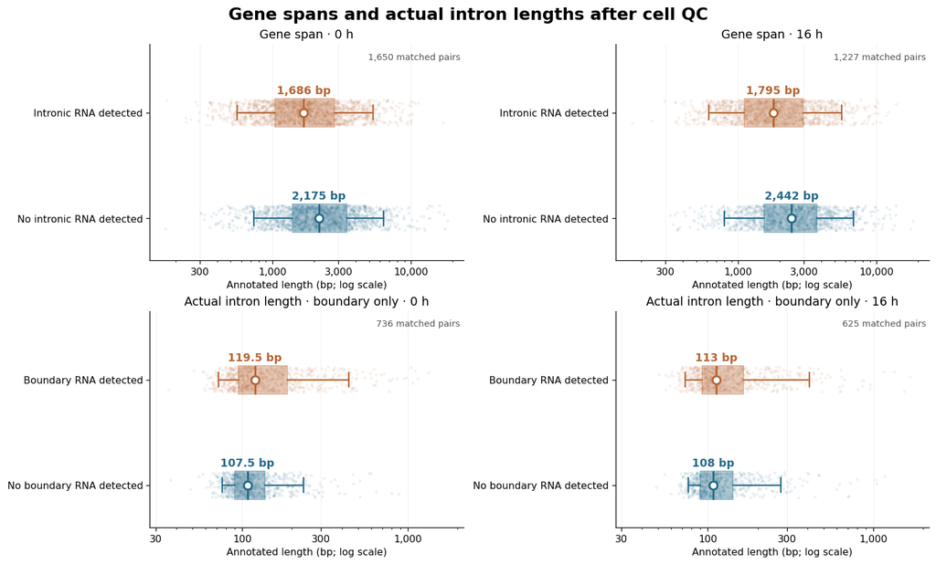

```python
# Gene-level spans above; actual boundary-supported introns below. Different matched units.
from matplotlib.ticker import FixedLocator, FuncFormatter, NullFormatter


# Load the completed fixed-window result and verify its cohort and expression inputs.
BOUNDARY = RESULTS / "chuck_boundary_only/20260908_fixed10"
boundary_complete = json.loads(record_input(BOUNDARY / "COMPLETE.json").read_text())
assert boundary_complete["status"] == "PASS" and boundary_complete["cells"] == len(keep)
for name, expected in boundary_complete["output_sha256"].items():
    assert digest(record_input(BOUNDARY / name)) == expected, name
boundary_gene_path = Path(next(p for p in boundary_complete["input_sha256"]
                              if p.endswith("/core_filtered_gene_counts.tsv")))
assert digest(record_input(boundary_gene_path)) == boundary_complete["input_sha256"][str(boundary_gene_path)]
boundary_cohort = json.loads(record_input(boundary_gene_path.with_name("core_filtered_run.json")).read_text())
assert set(boundary_cohort["retained_cells"]) == set(keep)
boundary_genes = pd.read_csv(boundary_gene_path, sep="\t").set_index("gene_id")
pd.testing.assert_frame_equal(boundary_genes.sort_index(), filtered_genes.sort_index())
boundary_matches = json.loads((BOUNDARY / "matching.json").read_text())
boundary_catalog = pd.read_csv(BOUNDARY / "intron_catalog.tsv", sep="\t").set_index("intron_id")
boundary_summary = pd.read_csv(BOUNDARY / "length_comparison.tsv", sep="\t", dtype={"hour": str})
boundary_medians = boundary_summary.set_index(["hour", "rule"])

overview_matches = json.loads(match_outputs["strict"].read_text())
plot_groups = {(row, hour): (overview_matches["cohorts"][hour] if row == 0
                             else boundary_matches[f"{hour}_either"])
               for row in (0, 1) for hour in ("00", "16")}
plot_tables = (structures, boundary_catalog)
fig, axes = plt.subplots(2, 2, figsize=(13, 7.8), constrained_layout=True)
rng = np.random.default_rng(20260908)
series = [("case", "Intron detected", "#b66534", 1),
          ("control", "Not detected", "#256a8a", 0)]

for row, (feature, title) in enumerate(
        (("gene_span_bp", "Gene span"), ("length_bp", "Actual intron length · boundary only"))):
    # Derive common row limits from every plotted value; no genes are trimmed out.
    arrays = {}
    for hour in ("00", "16"):
        cohort = plot_groups[(row, hour)]
        if cohort["matching_gate"] == "PASS":
            for role, _, _, _ in series:
                ids = [pair[role]["gene_id"] for pair in cohort["pairs"]]
                arrays[(hour, role)] = plot_tables[row].loc[ids, feature].to_numpy(dtype=float)
    if not arrays:
        for ax in axes[row]:
            ax.text(.5, .5, "Withheld: matching requires review", ha="center", transform=ax.transAxes)
        continue
    pooled = np.concatenate(list(arrays.values()))
    lo, hi = float(pooled.min() / 1.3), float(pooled.max() * 1.3)
    ticks = [m * 10.0 ** power
             for power in range(int(np.floor(np.log10(lo))), int(np.ceil(np.log10(hi))) + 1)
             for m in (1, 3) if lo <= m * 10.0 ** power <= hi]
    for col, hour in enumerate(("00", "16")):
        ax = axes[row, col]
        cohort = plot_groups[(row, hour)]
        if cohort["matching_gate"] != "PASS":
            ax.text(.5, .5, "Withheld: matching requires review", ha="center", transform=ax.transAxes)
            continue
        for role, label, color, position in series:
            values = arrays[(hour, role)]
            ax.scatter(values, position + rng.uniform(-.12, .12, len(values)),
                       s=9, color=color, alpha=.09, edgecolors="none", rasterized=True, zorder=1)
            ax.boxplot([values], positions=[position], vert=False, widths=.27,
                       whis=(5, 95), showfliers=False, patch_artist=True, manage_ticks=False,
                       boxprops=dict(facecolor=color, edgecolor=color, alpha=.35),
                       whiskerprops=dict(color=color, linewidth=1.5),
                       capprops=dict(color=color, linewidth=1.5),
                       medianprops=dict(color=color, linewidth=2))
            median = float(np.median(values))
            expected_median = (length_outputs["strict"]["cohorts"][hour]["length_comparison"][feature][
                "case_bp" if role == "case" else "control_bp"]["median"] if row == 0 else
                boundary_medians.loc[(hour, "either"), f"{role}_median_bp"])
            assert median == expected_median
            ax.scatter([median], [position], s=65, facecolor="white", edgecolor=color,
                       linewidth=2, zorder=4)
            ax.annotate(f"{median:,.1f} bp".replace(".0 bp", " bp"), (median, position), xytext=(0, 19),
                        textcoords="offset points", ha="center", color=color,
                        fontsize=11, fontweight="bold")
        ax.set(xscale="log", xlim=(lo, hi), ylim=(-.4, 1.65),
               xlabel="Annotated length (bp; log scale)",
               title=f"{title} · {int(hour)} h")
        ax.set_yticks([1, 0], ["Intronic RNA detected", "No intronic RNA detected"] if row == 0
                      else ["Boundary RNA detected", "No boundary RNA detected"])
        ax.xaxis.set_major_locator(FixedLocator(ticks))
        ax.xaxis.set_major_formatter(FuncFormatter(lambda x, _: f"{x:,.0f}"))
        ax.xaxis.set_minor_formatter(NullFormatter())
        ax.grid(axis="x", alpha=.16, zorder=0)
        ax.text(.99, .96, f"{cohort['matched_pairs']:,} matched pairs",
                transform=ax.transAxes, ha="right", va="top", fontsize=9, color="#555555")
fig.suptitle("Gene spans and actual intron lengths after cell QC", fontsize=17, fontweight="bold")
fig.savefig(OUT / "core_filtered_length_overview.png", dpi=180)
plt.show()
```

```python
# Save explicit cohort membership and code provenance; do not alter prior results.
import hashlib
notebook_path = ROOT / "notebooks/chuck_total_rna_cell_qc.ipynb"
notebook_cells = json.loads(notebook_path.read_text())["cells"]
code_source = "\n".join("".join(c["source"]) if isinstance(c["source"], list) else c["source"]
                        for c in notebook_cells if c["cell_type"] == "code")
manifest = dict(purpose="Core-only cell filtering and expression-matched length analysis.",
                run_utc=RUN_UTC, filtering_policy="core_review only; diagnostic-only cells retained",
                retained_cells=keep.tolist(),
                excluded_cells=json.loads(qc.loc[removed, ["hour", "plate", "core_reasons"]]
                                          .reset_index().to_json(orient="records")),
                cell_flow=json.loads(cell_flow.reset_index().to_json(orient="records")),
                balance=json.loads(balance_table.to_json(orient="records")),
                input_sha256=input_hashes, notebook_code_sha256=hashlib.sha256(code_source.encode()).hexdigest(),
                original_count_files_modified=False, qc_thresholds_refitted_after_exclusion=False)
with (OUT / "core_filtered_run.json").open("x") as handle:
    json.dump(manifest, handle, indent=2, allow_nan=False)
print("Filtered analysis, membership lists, matching results and lengths saved to:", OUT.relative_to(ROOT))
```

```
Filtered analysis, membership lists, matching results and lengths saved to: results/splicing_speed_comparison/chuck_cell_qc/20260908T142129637321Z
```

### Gene-span interpretation

Under the stronger gene-level definition, detected genes have **about 21% shorter spans at 0 h and 25% shorter spans at 16 h** than expression-matched controls. This challenges the simple prediction that intronic RNA should preferentially be detected in longer genes.

This does not tell us the length of the intron carrying the signal. We examine individual introns next, then restrict detection to fixed boundary windows in section 11. None of these comparisons directly measures splicing speed.

## 9. Which introns actually have detected RNA?

We now use **all 313 retained cells: 149 at 0 h and 164 at 16 h**, examining 14,392 annotated introns in 7,785 selected nuclear coding genes. The unit is an individual intron, and its length is the annotated distance from its start to its end. This is not a survey of every RNA type.

We include reads inside an intron and reads continuing across an exon–intron boundary. A 147-base read can support a 51-base intron even though it cannot fit entirely inside it. If a read supports two introns, both receive evidence, but we keep their shared read/UMI identity: they are not two independent molecules.

Boundary reads must have at least **10 aligned bases on each side**; we also report **5 bases** as a sensitivity check. These are practical evidence settings, not universal biological cutoffs. A read that skips the target intron through splicing is not counted as unspliced evidence. Weak, conflicting and excluded evidence is kept separate—not silently converted into absence.

These results reuse the same cell filter. No additional cells are removed based on intron detection.

```python
# Load only a completed whole-cohort recount; never substitute partial results.
FULL = RESULTS / "chuck_introns_full/20260908_core313"
completion = json.loads(record_input(FULL / "COMPLETE.json").read_text())
full_run = json.loads(record_input(FULL / "RUN_METADATA.json").read_text())
assert completion["status"] == "PASS" and completion["cells"] == len(keep)
assert set(full_run["retained_cells"]) == set(keep)
assert digest(FULL / "RUN_METADATA.json") == completion["run_metadata_sha256"]
for name, expected in completion["output_sha256"].items():
    assert digest(record_input(FULL / name)) == expected, name
intron_counts = pd.read_csv(FULL / "intron_counts.tsv", sep="\t", dtype={"hour": str})
intron_catalog = pd.read_csv(FULL / "intron_catalog.tsv", sep="\t").set_index("intron_id")
assert not intron_counts.duplicated(["hour", "rule", "intron_id"]).any()
assert intron_counts["length_bp"].eq(intron_counts["end"] - intron_counts["start"] + 1).all()
assert intron_counts.groupby(["hour", "rule"]).size().eq(len(intron_catalog)).all()
assert intron_counts["assigned_umis"].ge(intron_counts["detected_cells"]).all()
rule_titles = {"body_only": "Inside only", "boundary_5bp": "Inside + boundary (5 bp)",
               "boundary_10bp": "Inside + boundary (10 bp)"}
length_overview = []
for (hour, rule), frame in intron_counts.groupby(["hour", "rule"]):
    if rule not in rule_titles:
        continue
    detected = frame.loc[frame["assigned_umis"].gt(0)]
    strong = frame.loc[frame["assigned_umis"].ge(2) & frame["detected_cells"].ge(2)]
    length_overview.append({"time": f"{int(hour)} h", "evidence": rule_titles[rule],
                           "detected introns": len(detected), "median length (bp)": detected["length_bp"].median(),
                           "introns detected in >=2 cells": len(strong)})
display(pd.DataFrame(length_overview))
display(Markdown("**Examples from the actual intron table:** counts below are deduplicated within each cell and intron."))
examples = intron_counts.loc[intron_counts["rule"].eq("boundary_10bp") & intron_counts["assigned_umis"].gt(0)]
display(examples.sort_values(["hour", "gene_id", "start"]).groupby("hour", sort=False).head(4)[
    ["hour", "gene_id", "gene_name", "intron_id", "length_bp", "assigned_umis", "detected_cells"]])
pd.DataFrame(length_overview).to_csv(OUT / "actual_intron_length_overview.tsv", sep="\t", index=False)
```

|  | time | evidence | detected introns | median length (bp) | introns detected in >=2 cells |
| --- | --- | --- | --- | --- | --- |
| 0 | 0 h | Inside only | 1331 | 147.0 | 488 |
| 1 | 0 h | Inside + boundary (10 bp) | 2638 | 120.0 | 1219 |
| 2 | 0 h | Inside + boundary (5 bp) | 3082 | 117.0 | 1489 |
| 3 | 16 h | Inside only | 821 | 156.0 | 266 |
| 4 | 16 h | Inside + boundary (10 bp) | 2241 | 114.0 | 935 |
| 5 | 16 h | Inside + boundary (5 bp) | 2497 | 113.0 | 1066 |

**Examples from the actual intron table:** counts below are deduplicated within each cell and intron.

|  | hour | gene_id | gene_name | intron_id | length_bp | assigned_umis | detected_cells |
| --- | --- | --- | --- | --- | --- | --- | --- |
| 43185 | 00 | DDB_G0267374 | acpA | DDB_G0267374\|chr1:1647890-1648000:+ | 111 | 2 | 2 |
| 43189 | 00 | DDB_G0267380 | argE | DDB_G0267380\|chr1:415470-415543:+ | 74 | 1 | 1 |
| 43190 | 00 | DDB_G0267384 | culB | DDB_G0267384\|chr1:551836-551943:- | 108 | 1 | 1 |
| 43193 | 00 | DDB_G0267384 | culB | DDB_G0267384\|chr1:553071-553225:- | 155 | 2 | 2 |
| 100755 | 16 | DDB_G0267378 | aqpA | DDB_G0267378\|chr1:1385710-1385815:+ | 106 | 1 | 1 |
| 100761 | 16 | DDB_G0267384 | culB | DDB_G0267384\|chr1:553071-553225:- | 155 | 1 | 1 |
| 100774 | 16 | DDB_G0267400 | hspD | DDB_G0267400\|chr1:1283203-1283355:- | 153 | 1 | 1 |
| 100780 | 16 | DDB_G0267408 | psmA3 | DDB_G0267408\|chr1:278670-278768:- | 99 | 2 | 2 |

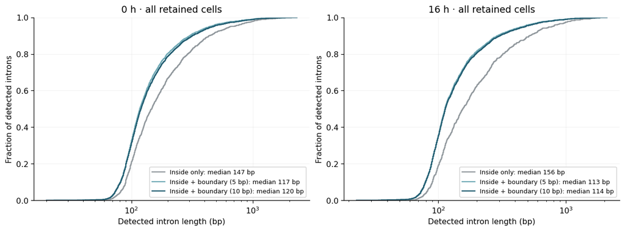

A curve further left represents shorter detected introns. Differences between rules show counting sensitivity—not a difference in splicing speed.

```python
# One length per detected intron per time point; no read/UMI weighting.
fig, axes = plt.subplots(1, 2, figsize=(11, 4), constrained_layout=True)
palette = {"body_only": "#92999e", "boundary_5bp": "#70aab6", "boundary_10bp": "#235e72"}
for ax, hour in zip(axes, ("00", "16")):
    for rule, title in rule_titles.items():
        values = np.sort(intron_counts.loc[intron_counts["hour"].eq(hour)
                         & intron_counts["rule"].eq(rule) & intron_counts["assigned_umis"].gt(0),
                         "length_bp"].to_numpy())
        ax.step(values, np.arange(1, len(values)+1)/len(values), where="post", color=palette[rule],
                label=f"{title}: median {np.median(values):g} bp")
    ax.set(xscale="log", ylim=(0, 1), title=f"{int(hour)} h · all retained cells",
           xlabel="Detected intron length (bp)", ylabel="Fraction of detected introns")
    ax.grid(alpha=.15)
    ax.legend(fontsize=8)
fig.savefig(OUT / "actual_intron_counting_rules.png", dpi=150)
plt.show()
display(Markdown("A curve further left represents shorter detected introns. "
                 "Differences between rules show counting sensitivity—not a difference in splicing speed."))
```

## 10. Are detected introns longer than comparable nondetected introns?

We compare introns whose **parent genes have similar amounts of sampled exon RNA**, separately at each time point. For example, a gene with 100 exon UMIs across 10 cells could be matched to one with 95 exon UMIs across 10 cells. Genes must have at least 20 exon UMIs across five retained cells.

The main comparison requires intronic support in **at least two cells**. Controls have **no qualifying intronic UMI and no unresolved intronic evidence**. Weak positives are omitted, not called controls. We also save the comparison allowing one detection.

For both boundary settings, we use introns at least 10 bases long with at least one adjacent exon at least 10 bases long. This gives each intron the geometric opportunity to meet the 10-base boundary rule; it is not a claim that every remaining annotation is correct. The complete length tables above retain the shorter annotated gaps.

Length is **not** used to choose matched pairs. Importantly, expression matching does **not** eliminate length-dependent RNA capture or mapping differences. This remains a descriptive comparison, not a measurement of persistence or splicing speed.

```python
# Reuse expression matching, with intron IDs as the unique feature identifiers.
from build_gene_structure import merge_intervals
models = read_mapping(GTF, set(intron_catalog["gene_id"]))
flank_lengths = {}
for gene, model in models.items():
    exons_merged = merge_intervals(model["exons"])
    for left, right in zip(exons_merged, exons_merged[1:]):
        flank_lengths[(gene, left[1]+1, right[0]-1)] = max(left[1]-left[0]+1, right[1]-right[0]+1)
intron_catalog["max_adjacent_exon_bp"] = [
    flank_lengths[(r.gene_id, r.start, r.end)] for r in intron_catalog.itertuples()]
intron_matches, intron_balance, actual_length_rows = {}, [], []
for hour in ("00", "16"):
    for rule in ("boundary_5bp", "boundary_10bp"):
        frame = intron_counts.loc[intron_counts["hour"].eq(hour) & intron_counts["rule"].eq(rule)].copy()
        frame["exon"] = frame["gene_id"].map(filtered_genes[f"chuck_{hour}hr_exon_umis"])
        frame["exon_cells"] = frame["gene_id"].map(filtered_genes[f"chuck_{hour}hr_cells_exon_detected"])
        frame["flank_bp"] = frame["intron_id"].map(intron_catalog["max_adjacent_exon_bp"])
        eligible = frame.loc[frame["exon"].ge(20) & frame["exon_cells"].ge(5)
                             & frame["length_bp"].ge(10) & frame["flank_bp"].ge(10)]
        for definition, minimum in (("original", 1), ("stronger", 2)):
            cases = eligible.loc[eligible["assigned_umis"].ge(minimum) & eligible["detected_cells"].ge(minimum)]
            controls = eligible.loc[eligible["assigned_umis"].eq(0) & eligible["unassigned_evidence_cells"].eq(0)]
            def matching_records(table):
                return [{"gene_id": r.intron_id, "parent_gene_id": r.gene_id,
                         "exon": int(r.exon), "exon_cells": int(r.exon_cells)}
                        for r in table.sort_values("intron_id").itertuples()]
            result = match_groups(matching_records(cases), matching_records(controls),
                                  max_cases=0, seed=20260908, caliper=.25)
            key = f"{hour}_{rule}_{definition}"
            intron_matches[key] = result
            intron_balance.append({"time": f"{int(hour)} h", "rule": rule, "definition": definition,
                                   "eligible introns": len(eligible), "cases": len(cases), "clean controls": len(controls),
                                   "matched pairs": result["matched_pairs"], "gate": result["matching_gate"],
                                   "exon SMD": result["balance"]["log2_exon_umis_plus_1"]["after_smd"],
                                   "cells SMD": result["balance"]["log2_exon_cells_plus_1"]["after_smd"]})
            if result["matching_gate"] != "PASS":
                continue
            case_ids = [p["case"]["gene_id"] for p in result["pairs"]]
            control_ids = [p["control"]["gene_id"] for p in result["pairs"]]
            a = intron_catalog.loc[case_ids, "length_bp"].to_numpy(dtype=float)
            b = intron_catalog.loc[control_ids, "length_bp"].to_numpy(dtype=float)
            actual_length_rows.append({"time": f"{int(hour)} h", "rule": rule, "definition": definition,
                                       "pairs": len(a), "detected median (bp)": float(np.median(a)),
                                       "control median (bp)": float(np.median(b)),
                                       "median paired length ratio": float(2**np.median(np.log2(a/b)))})
intron_balance = pd.DataFrame(intron_balance)
actual_length_table = pd.DataFrame(actual_length_rows, columns=["time", "rule", "definition", "pairs", "detected median (bp)", "control median (bp)", "median paired length ratio"])
display(intron_balance.loc[intron_balance["definition"].eq("stronger")].round(4))
display(actual_length_table.loc[actual_length_table["definition"].eq("stronger")].round(3))
with (OUT / "actual_intron_matching.json").open("x") as handle:
    json.dump(intron_matches, handle, indent=2, allow_nan=False)
intron_balance.to_csv(OUT / "actual_intron_matching_balance.tsv", sep="\t", index=False)
actual_length_table.to_csv(OUT / "actual_intron_length_comparison.tsv", sep="\t", index=False)
```

|  | time | rule | definition | eligible introns | cases | clean controls | matched pairs | gate | exon SMD | cells SMD |
| --- | --- | --- | --- | --- | --- | --- | --- | --- | --- | --- |
| 1 | 0 h | boundary_5bp | stronger | 10824 | 1375 | 6487 | 1319 | PASS | 0.0056 | -0.0001 |
| 3 | 0 h | boundary_10bp | stronger | 10824 | 1117 | 6487 | 1099 | PASS | 0.0034 | -0.0002 |
| 5 | 16 h | boundary_5bp | stronger | 9897 | 951 | 6605 | 945 | PASS | 0.0005 | -0.0030 |
| 7 | 16 h | boundary_10bp | stronger | 9897 | 828 | 6605 | 824 | PASS | 0.0002 | -0.0018 |

|  | time | rule | definition | pairs | detected median (bp) | control median (bp) | median paired length ratio |
| --- | --- | --- | --- | --- | --- | --- | --- |
| 1 | 0 h | boundary_5bp | stronger | 1319 | 130.0 | 106.0 | 1.203 |
| 3 | 0 h | boundary_10bp | stronger | 1099 | 134.0 | 105.0 | 1.263 |
| 5 | 16 h | boundary_5bp | stronger | 945 | 127.0 | 105.0 | 1.189 |
| 7 | 16 h | boundary_10bp | stronger | 824 | 128.0 | 105.0 | 1.203 |

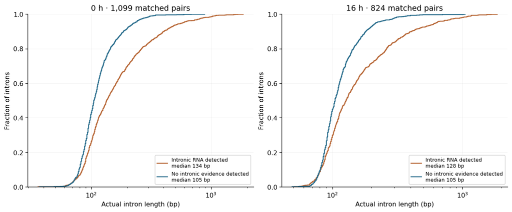

**0 h, 5bp boundary rule:** detected introns are approximately **20% longer** in the median paired comparison.

**0 h, 10bp boundary rule:** detected introns are approximately **26% longer** in the median paired comparison.

**16 h, 5bp boundary rule:** detected introns are approximately **19% longer** in the median paired comparison.

**16 h, 10bp boundary rule:** detected introns are approximately **20% longer** in the median paired comparison.

```python
# Compare actual intron lengths after matching; do not plot a failed comparison.
fig, axes = plt.subplots(1, 2, figsize=(11, 4.5), constrained_layout=True)
for ax, hour in zip(axes, ("00", "16")):
    result = intron_matches[f"{hour}_boundary_10bp_stronger"]
    if result["matching_gate"] != "PASS":
        ax.text(.5, .5, "Comparison withheld: expression balance needs review",
                ha="center", va="center", wrap=True, transform=ax.transAxes)
        continue
    for label, title, color in (("case", "Intronic RNA detected", "#b66534"),
                                ("control", "No intronic evidence detected", "#256a8a")):
        ids = [p[label]["gene_id"] for p in result["pairs"]]
        values = np.sort(intron_catalog.loc[ids, "length_bp"].to_numpy(dtype=float))
        ax.step(values, np.arange(1, len(values)+1)/len(values), where="post", color=color,
                label=f"{title}\nmedian {np.median(values):g} bp")
    ax.set(xscale="log", ylim=(0, 1), xlabel="Actual intron length (bp)", ylabel="Fraction of introns",
           title=f"{int(hour)} h · {result['matched_pairs']:,} matched pairs")
    ax.grid(alpha=.15)
    ax.legend(fontsize=8)
fig.savefig(OUT / "actual_intron_matched_lengths.png", dpi=150)
plt.show()
for row in actual_length_rows:
    if row["definition"] == "stronger":
        ratio = row["median paired length ratio"]
        direction = "longer" if ratio >= 1 else "shorter"
        anchor = row["rule"].split("_")[1]
        display(Markdown(f"**{row['time']}, {anchor} boundary rule:** detected introns are "
                         f"approximately **{abs(ratio-1)*100:.0f}% {direction}** in the median paired comparison."))
# Save provenance for the intron-resolved section as well as the earlier QC results.
with (OUT / "actual_intron_run.json").open("x") as handle:
    json.dump(dict(full_count_directory=str(FULL.relative_to(ROOT)), retained_cells=keep.tolist(),
                   input_sha256=input_hashes, counting_unit="cell/gene/intron/UMI",
                   comparison="Descriptive, expression-matched; detection/capture bias not fully adjusted.",
                   notebook_code_sha256=hashlib.sha256(code_source.encode()).hexdigest()),
              handle, indent=2)
```

### What this answers—and what it does not

These results describe **the lengths of the introns with actual supporting RNA**, using the full retained-cell dataset. They also show whether a length difference remains after matching parent-gene expression, and whether it changes with the boundary requirement.

They do **not** establish that longer introns are removed more slowly. Longer regions offer more opportunities for capture; sequence, annotation and mapping can also affect detection. Introns from the same gene and observations sharing a read/UMI are not independent replicates, so we do not report a significance test treating them as such.

We also do not interpret the difference between 0 h and 16 h as a splicing-speed change. Sampling depth and experimental batch relationships still need to be accounted for. Conventional scRNA-seq (AX4 and the genetic perturbations) and Rosengarten bulk RNA remain separate validation datasets, not pooled with Chuck/Zong.

## 11. Does the length difference remain with boundary-only evidence?

A long intron offers more places for an intron-body read to land. Here we ignore those reads and inspect the **same 20-base window at each boundary: 10 exon bases + 10 intron bases**. A read must cover the full window without a gap.

We require both windows to exist: introns at least 20 bp long and both flanking exons at least 10 bp. We compare either boundary, and the gene-strand-aware **5′ and 3′ boundaries separately**. A UMI supporting both ends is counted once in the either-end comparison.

As before, cases need **two UMIs across two cells**, and matching controls parent-gene exon expression and cell detection. Controls have **no qualifying or unresolved boundary evidence**; intron-body RNA alone does not disqualify them. Weak/conflicting evidence is omitted, not treated as absence.

The body-plus-boundary reference below is recomputed on the **same eligible introns**. All rows use all 313 retained cells, analyzed separately at 0 h and 16 h.

```python
# Show the completed fixed-window comparisons; never substitute a failed match.
boundary_titles = {"body_plus_boundary": "Body + boundary (same eligible introns)",
                   "either": "Boundary only · either end",
                   "5prime": "Boundary only · 5′ end", "3prime": "Boundary only · 3′ end"}
boundary_display = []
for rule, title in boundary_titles.items():
    row = {"Evidence": title}
    for hour in ("00", "16"):
        stats = boundary_medians.loc[(hour, rule)]
        row[f"{int(hour)} h"] = (f"{100 * (stats.paired_length_ratio - 1):+.1f}% ({int(stats.pairs):,} pairs)"
                                if stats.gate == "PASS" else "Withheld: matching requires review")
    boundary_display.append(row)
display(pd.DataFrame(boundary_display).set_index("Evidence"))
display(Markdown("Percentages are median **within-pair length differences**, not splicing rates. "
                 "All eight expression-balance checks passed; the full paired records are saved."))
boundary_summary.to_csv(OUT / "boundary_only_length_comparison.tsv", sep="\t", index=False)
with (OUT / "boundary_only_notebook_run.json").open("x") as handle:
    json.dump(dict(source=str(BOUNDARY.relative_to(ROOT)), retained_cells=keep.tolist(),
                   input_sha256=input_hashes, boundary_complete_sha256=digest(BOUNDARY / "COMPLETE.json"),
                   comparison="Descriptive fixed-window sensitivity; not mappability-normalized or a rate estimate."),
              handle, indent=2)
```

| Evidence | 0 h | 16 h |
| --- | --- | --- |
| Body + boundary (same eligible introns) | +24.7% (1,055 pairs) | +18.1% (791 pairs) |
| Boundary only · either end | +13.1% (736 pairs) | +6.4% (625 pairs) |
| Boundary only · 5′ end | +8.1% (386 pairs) | +0.0% (293 pairs) |
| Boundary only · 3′ end | +10.5% (375 pairs) | +7.1% (356 pairs) |

Percentages are median **within-pair length differences**, not splicing rates. All eight expression-balance checks passed; the full paired records are saved.

### What this tells us

**The length association becomes smaller:** about **13% at 0 h and 6% at 16 h** with either boundary, versus **25% and 18%** when body reads also contribute. At the 16 h 5′ boundary, the median paired difference is zero.

The earlier result is therefore **sensitive to how much intronic sequence can contribute evidence**. It is not a uniform ~20% shift across counting methods. Some descriptive association remains, but this does not prove slower removal of longer introns—or prove that the original association was entirely technical.

Fixed windows do not fully equalize mappability, read lengths or capture bias. The detected/control groups also change, and introns from the same gene are not independent replicates. We have not fitted a detection model or called annotated length “effective mappable length.” [Junction-based studies also address mappability explicitly](https://pmc.ncbi.nlm.nih.gov/articles/PMC4216919/).

## Sources

- [OSCA: basic cell QC](https://bioconductor.org/books/release/OSCA.basic/quality-control.html)
- [OSCA: batch-aware QC and its assumptions](https://bioconductor.org/books/release/OSCA.advanced/quality-control-redux.html)
- [Single-cell Best Practices: joint QC interpretation and additional preprocessing](https://www.sc-best-practices.org/preprocessing-visualization/quality-control/)
- [R documentation: scaled median absolute deviation](https://stat.ethz.ch/R-manual/R-devel/library/stats/html/mad.html)
- [Niu, Luo & Zong (2024): snapTotal-seq, including length-dependent detection](https://www.nature.com/articles/s41467-024-50291-3)
- [Windhager et al. (2012): intron-body and boundary reads in RNA processing analysis](https://pmc.ncbi.nlm.nih.gov/articles/3460197/)
- [featureCounts: feature-level observations versus gene-level counts](https://subread.sourceforge.net/featureCounts.html)
- [Braunschweig et al. (2014): boundary/junction evidence and mappability](https://pmc.ncbi.nlm.nih.gov/articles/PMC4216919/)